# TFM Data Science and Bussines Analytics, Sara Sirviente

#### RANDOM FOREST

Aplicamos Random Forest con PCA al conjunto -a- de variables:

```python
# Importar librerías necesarias
import pandas as pd
from sklearn.ensemble import RandomForestClassifier
from sklearn.model_selection import train_test_split
from sklearn.metrics import accuracy_score



# Crear el modelo de Random Forest con 100 árboles
modelo = RandomForestClassifier(n_estimators=100)

# Entrenar el modelo con el conjunto de entrenamiento
modelo.fit(X_t_a, Y_t_a)

# Predecir los resultados para el conjunto de prueba
predicciones = modelo.predict(X_test_a)

# Evaluar el desempeño del modelo utilizando la precisión (accuracy) como métrica
precision = accuracy_score(Y_test_a, predicciones)

print("La precisión del modelo es:", precision)

# Evaluacion modelo
CM_RF = confusion_matrix(Y_test_a,y_pred)
CR_RF = classification_report(Y_test_a,y_pred)
fprRF, recallRF, thresholdsRF = roc_curve(Y_test_a, y_pred)
AUC_RF = auc(fprRF, recallRF)

resultsRF = {"Confusion Matrix":CM_RF,"Classification Report":CR_RF,"Area Under Curve":AUC_RF}

# sprint resultado

for measure in resultsRF:
    print(measure,": \n",resultsRF[measure])
```

```
La precisión del modelo es: 0.9919524766003104
Confusion Matrix :
 [[1886362   19943]
 [   2456      25]]
Classification Report :
               precision    recall  f1-score   support

       False       1.00      0.99      0.99   1906305
        True       0.00      0.01      0.00      2481

    accuracy                           0.99   1908786
   macro avg       0.50      0.50      0.50   1908786
weighted avg       1.00      0.99      0.99   1908786

Area Under Curve :
 0.4998074911134564
```

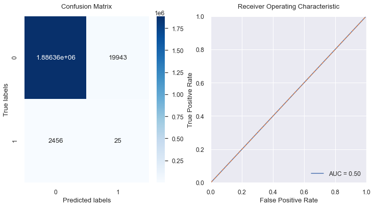

```python
# Obtener las probabilidades de la clase positiva para calcular la curva ROC
y_prob = modelo.predict_proba(X_test_a)[:, 1]

# Calcular la matriz de confusión
cm = confusion_matrix(Y_test_a, y_pred)

# Crear la figura y los subplots
fig, (ax1, ax2) = plt.subplots(1, 2, figsize=(12, 6))

# Crear la matriz de confusión
sns.heatmap(cm, annot=True, cmap='Blues', fmt='g', ax=ax1)

# Configurar las etiquetas de los ejes
ax1.set_xlabel('Predicted labels')
ax1.set_ylabel('True labels')
ax1.set_title('Confusion Matrix')

# Calcular la curva ROC y el área bajo la curva (AUC)
#fpr, tpr, thresholds = roc_curve(Y_test_a, y_prob)
#roc_auc = auc(fpr, tpr)

# Graficar la curva ROC
ax2.plot(fprRF, recallRF, label='AUC = %0.2f' % AUC_RF)
ax2.plot([0, 1], [0, 1], linestyle='--')
ax2.set_xlim([0.0, 1.0])
ax2.set_ylim([0.0, 1.0])
ax2.set_xlabel('False Positive Rate')
ax2.set_ylabel('True Positive Rate')
ax2.set_title('Receiver Operating Characteristic')
ax2.legend(loc="lower right")

# Mostrar la figura
plt.savefig('RF_Xa.tiff', dpi=300, format='tiff')
plt.show()
```

Aplicamos Random Forest con PCA al conjunto -b- de variables:

```python
# Crear el modelo de Random Forest con 100 árboles
modelo = RandomForestClassifier(n_estimators=100)

# Entrenar el modelo con el conjunto de entrenamiento
modelo.fit(X_t_b, Y_t_b)

# Predecir los resultados para el conjunto de prueba
predicciones = modelo.predict(X_test_b)

# Evaluar el desempeño del modelo utilizando la precisión (accuracy) como métrica
precision = accuracy_score(Y_test_b, predicciones)

print("La precisión del modelo es:", precision)

# Evaluacion modelo
CM_RF = confusion_matrix(Y_test_b,y_pred)
CR_RF = classification_report(Y_test_b,y_pred)
fprRF, recallRF, thresholdsRF = roc_curve(Y_test_b, y_pred)
AUC_RF = auc(fprRF, recallRF)

resultsRF = {"Confusion Matrix":CM_RF,"Classification Report":CR_RF,"Area Under Curve":AUC_RF}

# sprint resultado

for measure in resultsRF:
    print(measure,": \n",resultsRF[measure])
```

```
La precisión del modelo es: 0.9845530090853558
Confusion Matrix :
 [[1886419   19945]
 [   2399      23]]
Classification Report :
               precision    recall  f1-score   support

       False       1.00      0.99      0.99   1906364
        True       0.00      0.01      0.00      2422

    accuracy                           0.99   1908786
   macro avg       0.50      0.50      0.50   1908786
weighted avg       1.00      0.99      0.99   1908786

Area Under Curve :
 0.499516979462216
```

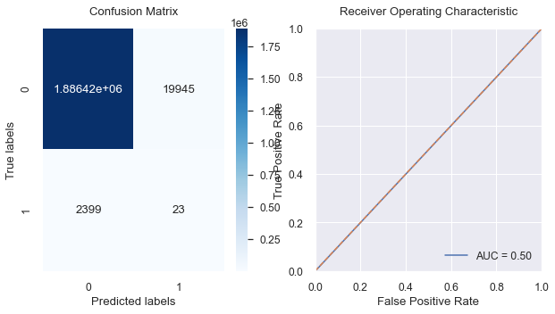

```python
# Obtener las probabilidades de la clase positiva para calcular la curva ROC
y_prob = modelo.predict_proba(X_test_b)[:, 1]

# Calcular la matriz de confusión
cm = confusion_matrix(Y_test_b, y_pred)

# Crear la figura y los subplots
fig, (ax1, ax2) = plt.subplots(1, 2, figsize=(12, 6))

# Crear la matriz de confusión
sns.heatmap(cm, annot=True, cmap='Blues', fmt='g', ax=ax1)

# Configurar las etiquetas de los ejes
ax1.set_xlabel('Predicted labels')
ax1.set_ylabel('True labels')
ax1.set_title('Confusion Matrix')

# Calcular la curva ROC y el área bajo la curva (AUC)
#fpr, tpr, thresholds = roc_curve(Y_test_a, y_prob)
#roc_auc = auc(fpr, tpr)

# Graficar la curva ROC
ax2.plot(fprRF, recallRF, label='AUC = %0.2f' % AUC_RF)
ax2.plot([0, 1], [0, 1], linestyle='--')
ax2.set_xlim([0.0, 1.0])
ax2.set_ylim([0.0, 1.0])
ax2.set_xlabel('False Positive Rate')
ax2.set_ylabel('True Positive Rate')
ax2.set_title('Receiver Operating Characteristic')
ax2.legend(loc="lower right")

# Mostrar la figura
plt.savefig('RF_Xb.tiff', dpi=300, format='tiff')
plt.show()
```

Aplicamos Random Forest con PCA al conjunto -c- de variables:

```python
# Crear el modelo de Random Forest con 100 árboles
modelo = RandomForestClassifier(n_estimators=100)

# Entrenar el modelo con el conjunto de entrenamiento
modelo.fit(X_t_c, Y_t_c)

# Predecir los resultados para el conjunto de prueba
predicciones = modelo.predict(X_test_c)

# Evaluar el desempeño del modelo utilizando la precisión (accuracy) como métrica
precision = accuracy_score(Y_test_c, predicciones)

print("La precisión del modelo es:", precision)

# Evaluacion modelo
CM_RF = confusion_matrix(Y_test_c,y_pred)
CR_RF = classification_report(Y_test_c,y_pred)
fprRF, recallRF, thresholdsRF = roc_curve(Y_test_c, y_pred)
AUC_RF = auc(fprRF, recallRF)

resultsRF = {"Confusion Matrix":CM_RF,"Classification Report":CR_RF,"Area Under Curve":AUC_RF}

# sprint resultado

for measure in resultsRF:
    print(measure,": \n",resultsRF[measure])
```

```
La precisión del modelo es: 0.8757299141967722
Confusion Matrix :
 [[1886356   19945]
 [   2462      23]]
Classification Report :
               precision    recall  f1-score   support

       False       1.00      0.99      0.99   1906301
        True       0.00      0.01      0.00      2485

    accuracy                           0.99   1908786
   macro avg       0.50      0.50      0.50   1908786
weighted avg       1.00      0.99      0.99   1908786

Area Under Curve :
 0.4993964311494248
```

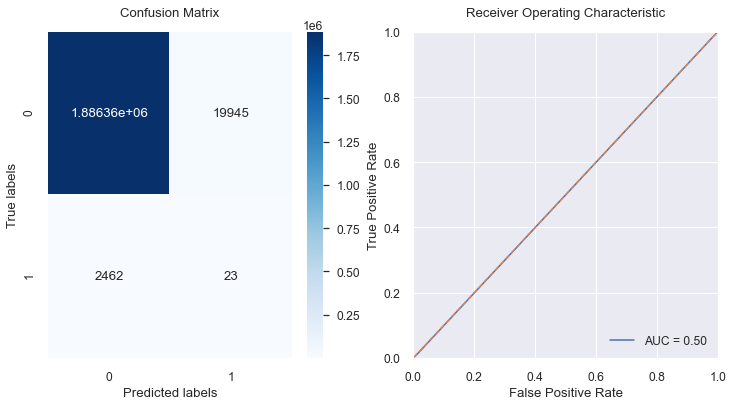

```python
# Obtener las probabilidades de la clase positiva para calcular la curva ROC
y_prob = modelo.predict_proba(X_test_c)[:, 1]

# Calcular la matriz de confusión
cm = confusion_matrix(Y_test_c, y_pred)

# Crear la figura y los subplots
fig, (ax1, ax2) = plt.subplots(1, 2, figsize=(12, 6))

# Crear la matriz de confusión
sns.heatmap(cm, annot=True, cmap='Blues', fmt='g', ax=ax1)

# Configurar las etiquetas de los ejes
ax1.set_xlabel('Predicted labels')
ax1.set_ylabel('True labels')
ax1.set_title('Confusion Matrix')

# Calcular la curva ROC y el área bajo la curva (AUC)
#fpr, tpr, thresholds = roc_curve(Y_test_a, y_prob)
#roc_auc = auc(fpr, tpr)

# Graficar la curva ROC
ax2.plot(fprRF, recallRF, label='AUC = %0.2f' % AUC_RF)
ax2.plot([0, 1], [0, 1], linestyle='--')
ax2.set_xlim([0.0, 1.0])
ax2.set_ylim([0.0, 1.0])
ax2.set_xlabel('False Positive Rate')
ax2.set_ylabel('True Positive Rate')
ax2.set_title('Receiver Operating Characteristic')
ax2.legend(loc="lower right")

# Mostrar la figura
plt.savefig('RF_Xc.tiff', dpi=300, format='tiff')
plt.show()
```

Aplicamos Random Forest con PCA al conjunto -d- de variables:

```python
# Crear el modelo de Random Forest con 100 árboles
modelo = RandomForestClassifier(n_estimators=100)

# Entrenar el modelo con el conjunto de entrenamiento
modelo.fit(X_t_d, Y_t_d)

# Predecir los resultados para el conjunto de prueba
predicciones = modelo.predict(X_test_d)

# Evaluar el desempeño del modelo utilizando la precisión (accuracy) como métrica
precision = accuracy_score(Y_test_d, predicciones)

print("La precisión del modelo es:", precision)

# Evaluacion modelo
CM_RF = confusion_matrix(Y_test_d,y_pred)
CR_RF = classification_report(Y_test_d,y_pred)
fprRF, recallRF, thresholdsRF = roc_curve(Y_test_d, y_pred)
AUC_RF = auc(fprRF, recallRF)

resultsRF = {"Confusion Matrix":CM_RF,"Classification Report":CR_RF,"Area Under Curve":AUC_RF}

# sprint resultado

for measure in resultsRF:
    print(measure,": \n",resultsRF[measure])
```

```
La precisión del modelo es: 0.9829367985724958
Confusion Matrix :
 [[1886378   19947]
 [   2440      21]]
Classification Report :
               precision    recall  f1-score   support

       False       1.00      0.99      0.99   1906325
        True       0.00      0.01      0.00      2461

    accuracy                           0.99   1908786
   macro avg       0.50      0.50      0.50   1908786
weighted avg       1.00      0.99      0.99   1908786

Area Under Curve :
 0.49903476415071185
```

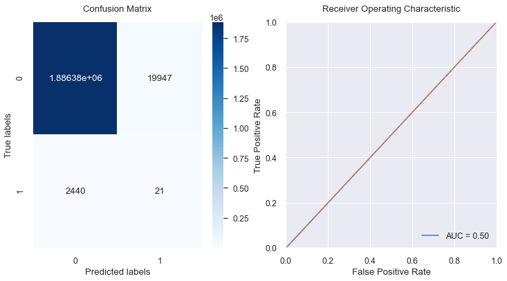

```python
# Obtener las probabilidades de la clase positiva para calcular la curva ROC
y_prob = modelo.predict_proba(X_test_d)[:, 1]

# Calcular la matriz de confusión
cm = confusion_matrix(Y_test_d, y_pred)

# Crear la figura y los subplots
fig, (ax1, ax2) = plt.subplots(1, 2, figsize=(12, 6))

# Crear la matriz de confusión
sns.heatmap(cm, annot=True, cmap='Blues', fmt='g', ax=ax1)

# Configurar las etiquetas de los ejes
ax1.set_xlabel('Predicted labels')
ax1.set_ylabel('True labels')
ax1.set_title('Confusion Matrix')

# Calcular la curva ROC y el área bajo la curva (AUC)
#fpr, tpr, thresholds = roc_curve(Y_test_a, y_prob)
#roc_auc = auc(fpr, tpr)

# Graficar la curva ROC
ax2.plot(fprRF, recallRF, label='AUC = %0.2f' % AUC_RF)
ax2.plot([0, 1], [0, 1], linestyle='--')
ax2.set_xlim([0.0, 1.0])
ax2.set_ylim([0.0, 1.0])
ax2.set_xlabel('False Positive Rate')
ax2.set_ylabel('True Positive Rate')
ax2.set_title('Receiver Operating Characteristic')
ax2.legend(loc="lower right")

# Mostrar la figura
plt.savefig('RF_Xd.tiff', dpi=300, format='tiff')
plt.show()
```

Aplicamos Random Forest con PCA al conjunto -e- de variables:

```python
# Crear el modelo de Random Forest con 100 árboles
modelo = RandomForestClassifier(n_estimators=100)

# Entrenar el modelo con el conjunto de entrenamiento
modelo.fit(X_t_e, Y_t_e)

# Predecir los resultados para el conjunto de prueba
predicciones = modelo.predict(X_test_e)

# Evaluar el desempeño del modelo utilizando la precisión (accuracy) como métrica
precision = accuracy_score(Y_test_e, predicciones)

print("La precisión del modelo es:", precision)

# Evaluacion modelo
CM_RF = confusion_matrix(Y_test_e,y_pred)
CR_RF = classification_report(Y_test_e,y_pred)
fprRF, recallRF, thresholdsRF = roc_curve(Y_test_e, y_pred)
AUC_RF = auc(fprRF, recallRF)

resultsRF = {"Confusion Matrix":CM_RF,"Classification Report":CR_RF,"Area Under Curve":AUC_RF}

# sprint resultado

for measure in resultsRF:
    print(measure,": \n",resultsRF[measure])
```

```
La precisión del modelo es: 0.978441794941916
Confusion Matrix :
 [[1886301   19925]
 [   2517      43]]
Classification Report :
               precision    recall  f1-score   support

       False       1.00      0.99      0.99   1906226
        True       0.00      0.02      0.00      2560

    accuracy                           0.99   1908786
   macro avg       0.50      0.50      0.50   1908786
weighted avg       1.00      0.99      0.99   1908786

Area Under Curve :
 0.5031721421918887
```

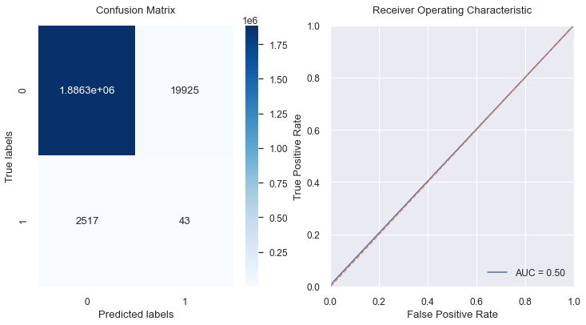

```python
# Obtener las probabilidades de la clase positiva para calcular la curva ROC
y_prob = modelo.predict_proba(X_test_e)[:, 1]

# Calcular la matriz de confusión
cm = confusion_matrix(Y_test_e, y_pred)

# Crear la figura y los subplots
fig, (ax1, ax2) = plt.subplots(1, 2, figsize=(12, 6))

# Crear la matriz de confusión
sns.heatmap(cm, annot=True, cmap='Blues', fmt='g', ax=ax1)

# Configurar las etiquetas de los ejes
ax1.set_xlabel('Predicted labels')
ax1.set_ylabel('True labels')
ax1.set_title('Confusion Matrix')

# Calcular la curva ROC y el área bajo la curva (AUC)
#fpr, tpr, thresholds = roc_curve(Y_test_a, y_prob)
#roc_auc = auc(fpr, tpr)

# Graficar la curva ROC
ax2.plot(fprRF, recallRF, label='AUC = %0.2f' % AUC_RF)
ax2.plot([0, 1], [0, 1], linestyle='--')
ax2.set_xlim([0.0, 1.0])
ax2.set_ylim([0.0, 1.0])
ax2.set_xlabel('False Positive Rate')
ax2.set_ylabel('True Positive Rate')
ax2.set_title('Receiver Operating Characteristic')
ax2.legend(loc="lower right")

# Mostrar la figura
plt.savefig('RF_Xe.tiff', dpi=300, format='tiff')
plt.show()
```

Aplicamos Random Forest con PCA al conjunto -f- de variables:

```python
# Crear el modelo de Random Forest con 100 árboles
modelo = RandomForestClassifier(n_estimators=100)

# Entrenar el modelo con el conjunto de entrenamiento
modelo.fit(X_t_f, Y_t_f)

# Predecir los resultados para el conjunto de prueba
predicciones = modelo.predict(X_test_f)

# Evaluar el desempeño del modelo utilizando la precisión (accuracy) como métrica
precision = accuracy_score(Y_test_f, predicciones)

print("La precisión del modelo es:", precision)

# Evaluacion modelo
CM_RF = confusion_matrix(Y_test_f,y_pred)
CR_RF = classification_report(Y_test_f,y_pred)
fprRF, recallRF, thresholdsRF = roc_curve(Y_test_f, y_pred)
AUC_RF = auc(fprRF, recallRF)

resultsRF = {"Confusion Matrix":CM_RF,"Classification Report":CR_RF,"Area Under Curve":AUC_RF}

# sprint resultado

for measure in resultsRF:
    print(measure,": \n",resultsRF[measure])
```

```
La precisión del modelo es: 0.9843036359235661
Confusion Matrix :
 [[1886395   19937]
 [   2423      31]]
Classification Report :
               precision    recall  f1-score   support

       False       1.00      0.99      0.99   1906332
        True       0.00      0.01      0.00      2454

    accuracy                           0.99   1908786
   macro avg       0.50      0.50      0.50   1908786
weighted avg       1.00      0.99      0.99   1908786

Area Under Curve :
 0.5010870663089921
```

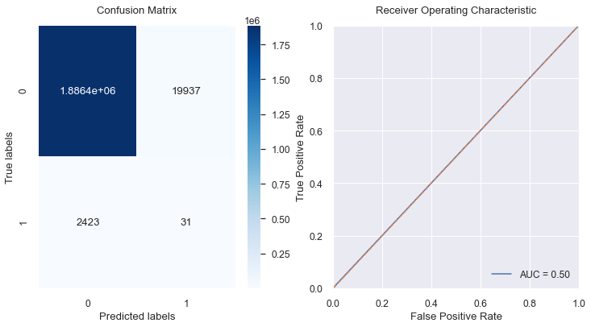

```python
# Obtener las probabilidades de la clase positiva para calcular la curva ROC
y_prob = modelo.predict_proba(X_test_f)[:, 1]

# Calcular la matriz de confusión
cm = confusion_matrix(Y_test_f, y_pred)

# Crear la figura y los subplots
fig, (ax1, ax2) = plt.subplots(1, 2, figsize=(12, 6))

# Crear la matriz de confusión
sns.heatmap(cm, annot=True, cmap='Blues', fmt='g', ax=ax1)

# Configurar las etiquetas de los ejes
ax1.set_xlabel('Predicted labels')
ax1.set_ylabel('True labels')
ax1.set_title('Confusion Matrix')
# Calcular la curva ROC y el área bajo la curva (AUC)
#fpr, tpr, thresholds = roc_curve(Y_test_a, y_prob)
#roc_auc = auc(fpr, tpr)

# Graficar la curva ROC
ax2.plot(fprRF, recallRF, label='AUC = %0.2f' % AUC_RF)
ax2.plot([0, 1], [0, 1], linestyle='--')
ax2.set_xlim([0.0, 1.0])
ax2.set_ylim([0.0, 1.0])
ax2.set_xlabel('False Positive Rate')
ax2.set_ylabel('True Positive Rate')
ax2.set_title('Receiver Operating Characteristic')
ax2.legend(loc="lower right")

# Mostrar la figura
plt.savefig('RF_Xf.tiff', dpi=300, format='tiff')
plt.show()
```

Aplicamos Random Forest con PCA al conjunto -g de variables:

```python
# Crear el modelo de Random Forest con 100 árboles
modelo = RandomForestClassifier(n_estimators=100)

# Entrenar el modelo con el conjunto de entrenamiento
modelo.fit(X_t_g, Y_t_g)

# Predecir los resultados para el conjunto de prueba
predicciones = modelo.predict(X_test_g)

# Evaluar el desempeño del modelo utilizando la precisión (accuracy) como métrica
precision = accuracy_score(Y_test_g, predicciones)

print("La precisión del modelo es:", precision)

# Evaluacion modelo
CM_RF = confusion_matrix(Y_test_g,y_pred)
CR_RF = classification_report(Y_test_g,y_pred)
fprRF, recallRF, thresholdsRF = roc_curve(Y_test_g, y_pred)
AUC_RF = auc(fprRF, recallRF)

resultsRF = {"Confusion Matrix":CM_RF,"Classification Report":CR_RF,"Area Under Curve":AUC_RF}

# sprint resultado

for measure in resultsRF:
    print(measure,": \n",resultsRF[measure])
```

```
La precisión del modelo es: 0.9928520012196234
Confusion Matrix :
 [[1886381   19951]
 [   2437      17]]
Classification Report :
               precision    recall  f1-score   support

       False       1.00      0.99      0.99   1906332
        True       0.00      0.01      0.00      2454

    accuracy                           0.99   1908786
   macro avg       0.50      0.50      0.50   1908786
weighted avg       1.00      0.99      0.99   1908786

Area Under Curve :
 0.49823090859822833
```